# World-Population-Analysis

Sabelo Zwane

2023-12-21

## Read the data files

```r
w_data <- read.csv('World_pop_data_2023-11-14 11_56_30.csv')
head(w_data)
```

```
##   Country.Code      Indicator.Name Indicator.Code     X1960     X1961     X1962
## 1          ABW "Population, total"    SP.POP.TOTL     54208     55434     56234
## 2          AFE "Population, total"    SP.POP.TOTL 130836765 134159786 137614644
## 3          AFG "Population, total"    SP.POP.TOTL   8996967   9169406   9351442
## 4          AFW "Population, total"    SP.POP.TOTL  96396419  98407221 100506960
## 5          AGO "Population, total"    SP.POP.TOTL   5454938   5531451   5608499
## 6          ALB "Population, total"    SP.POP.TOTL   1608800   1659800   1711319
##       X1963     X1964     X1965     X1966     X1967     X1968     X1969
## 1     56699     57029     57357     57702     58044     58377     58734
## 2 141202036 144920186 148769974 152752671 156876454 161156430 165611760
## 3   9543200   9744772   9956318  10174840  10399936  10637064  10893772
## 4 102691339 104953470 107289875 109701811 112195950 114781116 117468741
## 5   5679409   5734995   5770573   5781305   5774440   5771973   5803677
## 6   1762621   1814135   1864791   1914573   1965598   2022272   2081695
##       X1970     X1971     X1972     X1973     X1974     X1975     X1976
```

[output cut: 55 more lines]

## Open the second data file

```r
metadata <- read.csv('country_metadata_2023-11-14 11_59_06.csv')
head(metadata)
```

```
##   Country.Code                    Region         IncomeGroup
## 1          ABW Latin America & Caribbean         High income
## 2          AFE                      null                null
## 3          AFG                South Asia          Low income
## 4          AFW                      null                null
## 5          AGO        Sub-Saharan Africa Lower middle income
## 6          ALB     Europe & Central Asia Upper middle income
##                                                                                                                                                                                                                            SpecialNotes
## 1                                                                                                                                                                                                                                  null
## 2                                                                  "26 countries, stretching from the Red Sea in the North to the Cape of Good Hope in the South (https://www.worldbank.org/en/region/afr/eastern-and-southern-africa)"
## 3                                                                                                                                                           Fiscal year end: March 20; reporting period for national accounts data: FY.
## 4 "22 countries, stretching from the westernmost point of Africa, across the equator, and partly along the Atlantic Ocean till the Republic of Congo in the South (https://www.worldbank.org/en/region/afr/western-and-central-africa)"
## 5                                                                                                                                                                                                                                  null
## 6                                                                                                                                                                                                                                  null
##                     TableName
## 1                       Aruba
## 2 Africa Eastern and Southern
## 3                 Afghanistan
## 4  Africa Western and Central
## 5                      Angola
## 6                     Albania
```

## Check out the column names of the fisrt file

```r
colnames(w_data)
```

```
##  [1] "Country.Code"   "Indicator.Name" "Indicator.Code" "X1960"
##  [5] "X1961"          "X1962"          "X1963"          "X1964"
##  [9] "X1965"          "X1966"          "X1967"          "X1968"
## [13] "X1969"          "X1970"          "X1971"          "X1972"
## [17] "X1973"          "X1974"          "X1975"          "X1976"
## [21] "X1977"          "X1978"          "X1979"          "X1980"
## [25] "X1981"          "X1982"          "X1983"          "X1984"
## [29] "X1985"          "X1986"          "X1987"          "X1988"
## [33] "X1989"          "X1990"          "X1991"          "X1992"
## [37] "X1993"          "X1994"          "X1995"          "X1996"
## [41] "X1997"          "X1998"          "X1999"          "X2000"
## [45] "X2001"          "X2002"          "X2003"          "X2004"
## [49] "X2005"          "X2006"          "X2007"          "X2008"
## [53] "X2009"          "X2010"          "X2011"          "X2012"
## [57] "X2013"          "X2014"          "X2015"          "X2016"
## [61] "X2017"          "X2018"          "X2019"          "X2020"
```

## Check out the column names of the second file

```r
colnames(metadata)
```

```
## [1] "Country.Code" "Region"       "IncomeGroup"  "SpecialNotes" "TableName"
```

## We need to select the columns we want only

```r
new_w_data <- w_data[c(-2,-3)]
new_metadata <- metadata[c(-4)]
```

## We want to join the two data frames using the merge function from the dyplr package

## load the dyplr package

```r
library(dplyr)
```

```r
pop_data <- merge(x = new_metadata, y = new_w_data, by = "Country.Code")
```

##Rename Column four to Country

```r
colnames(pop_data)[4] <- "CountryName"
```

## Clean the data and Check rows with null values.

```r
any(is.null(pop_data))
```

```
## [1] FALSE
```

## We find the rows that contain the value “null” a different way.

```r
null_values <- pop_data%>%filter_all(any_vars(.%in%c('null')))
```

## Remove the rows with the null values in region as these are not countries

```r
pop_data <- subset(pop_data, Region!="null")
head(pop_data)
```

```
##   Country.Code                     Region         IncomeGroup
## 1          ABW  Latin America & Caribbean         High income
## 3          AFG                 South Asia          Low income
## 5          AGO         Sub-Saharan Africa Lower middle income
## 6          ALB      Europe & Central Asia Upper middle income
## 7          AND      Europe & Central Asia         High income
## 9          ARE Middle East & North Africa         High income
##            CountryName   X1960   X1961   X1962   X1963   X1964   X1965    X1966
## 1                Aruba   54208   55434   56234   56699   57029   57357    57702
## 3          Afghanistan 8996967 9169406 9351442 9543200 9744772 9956318 10174840
## 5               Angola 5454938 5531451 5608499 5679409 5734995 5770573  5781305
## 6              Albania 1608800 1659800 1711319 1762621 1814135 1864791  1914573
## 7              Andorra   13410   14378   15379   16407   17466   18542    19646
## 9 United Arab Emirates   92417  100801  112112  125130  138049  149855   159979
##      X1967    X1968    X1969    X1970    X1971    X1972    X1973    X1974
```

[output cut: 48 more lines]

## Stack the columns of the different years. This can also be achieved using the melt() function

## Bind the first four columns

## Stack the rest of the columns

```r
stacked_pop_data <- cbind(pop_data[1:4], stack(pop_data[5:65]))
```

## Remove the X on the Years data

```r
stacked_pop_data$ind <- substr(stacked_pop_data$ind, 2, 5)
```

## Change the column heading from ind to Year

```r
colnames(stacked_pop_data)[6] <- 'Year'
```

## Check the structure of the dataframe

```r
str(stacked_pop_data)
```

```
## 'data.frame':    13237 obs. of  6 variables:
##  $ Country.Code: chr  "ABW" "AFG" "AGO" "ALB" ...
##  $ Region      : chr  "Latin America & Caribbean" "South Asia" "Sub-Saharan Africa" "Europe & Central Asia" ...
##  $ IncomeGroup : chr  "High income" "Low income" "Lower middle income" "Upper middle income" ...
##  $ CountryName : chr  "Aruba" "Afghanistan" "Angola" "Albania" ...
##  $ values      : num  54208 8996967 5454938 1608800 13410 ...
##  $ Year        : chr  "1960" "1960" "1960" "1960" ...
```

## Change the data type of Year from string to number

```r
stacked_pop_data$Year <- as.numeric(stacked_pop_data$Year)
```

## Create a date column Using lubridate

```r
library(lubridate)
stacked_pop_data$Date <- ymd(stacked_pop_data$Year, truncated = 2L)
head(stacked_pop_data)
```

```
##   Country.Code                     Region         IncomeGroup
## 1          ABW  Latin America & Caribbean         High income
## 2          AFG                 South Asia          Low income
## 3          AGO         Sub-Saharan Africa Lower middle income
## 4          ALB      Europe & Central Asia Upper middle income
## 5          AND      Europe & Central Asia         High income
## 6          ARE Middle East & North Africa         High income
##            CountryName  values Year       Date
## 1                Aruba   54208 1960 1960-01-01
## 2          Afghanistan 8996967 1960 1960-01-01
## 3               Angola 5454938 1960 1960-01-01
## 4              Albania 1608800 1960 1960-01-01
## 5              Andorra   13410 1960 1960-01-01
## 6 United Arab Emirates   92417 1960 1960-01-01
```

## Check the structure of the dataframe again

```r
str(stacked_pop_data)
```

```
## 'data.frame':    13237 obs. of  7 variables:
##  $ Country.Code: chr  "ABW" "AFG" "AGO" "ALB" ...
##  $ Region      : chr  "Latin America & Caribbean" "South Asia" "Sub-Saharan Africa" "Europe & Central Asia" ...
##  $ IncomeGroup : chr  "High income" "Low income" "Lower middle income" "Upper middle income" ...
##  $ CountryName : chr  "Aruba" "Afghanistan" "Angola" "Albania" ...
##  $ values      : num  54208 8996967 5454938 1608800 13410 ...
##  $ Year        : num  1960 1960 1960 1960 1960 1960 1960 1960 1960 1960 ...
##  $ Date        : Date, format: "1960-01-01" "1960-01-01" ...
```

## We can Output the data frame as csv

## write.csv(stacked_pop_data , “C:\Users\Sabelo\Documents\Grad School\GIES\MSBA\Learning\Word Population Project\WorldPop\Population_data.csv”, row.names=FALSE)

## Scale the population values for more clear presentation and check for null values

```r
stacked_pop_data$values <- stacked_pop_data$values/1000000
stacked_pop_data <- na.omit(stacked_pop_data)
sum(is.na(stacked_pop_data))
```

```
## [1] 0
```

```r
head(stacked_pop_data)
```

```
##   Country.Code                     Region         IncomeGroup
## 1          ABW  Latin America & Caribbean         High income
## 2          AFG                 South Asia          Low income
## 3          AGO         Sub-Saharan Africa Lower middle income
## 4          ALB      Europe & Central Asia Upper middle income
## 5          AND      Europe & Central Asia         High income
## 6          ARE Middle East & North Africa         High income
##            CountryName   values Year       Date
## 1                Aruba 0.054208 1960 1960-01-01
## 2          Afghanistan 8.996967 1960 1960-01-01
## 3               Angola 5.454938 1960 1960-01-01
## 4              Albania 1.608800 1960 1960-01-01
## 5              Andorra 0.013410 1960 1960-01-01
## 6 United Arab Emirates 0.092417 1960 1960-01-01
```

## Now that we cleaned the data, we can do some analysis

## load ggplot package for graphing

```r
library(ggplot2)
```

## Plot a line graph to show changes to population for the chosen country

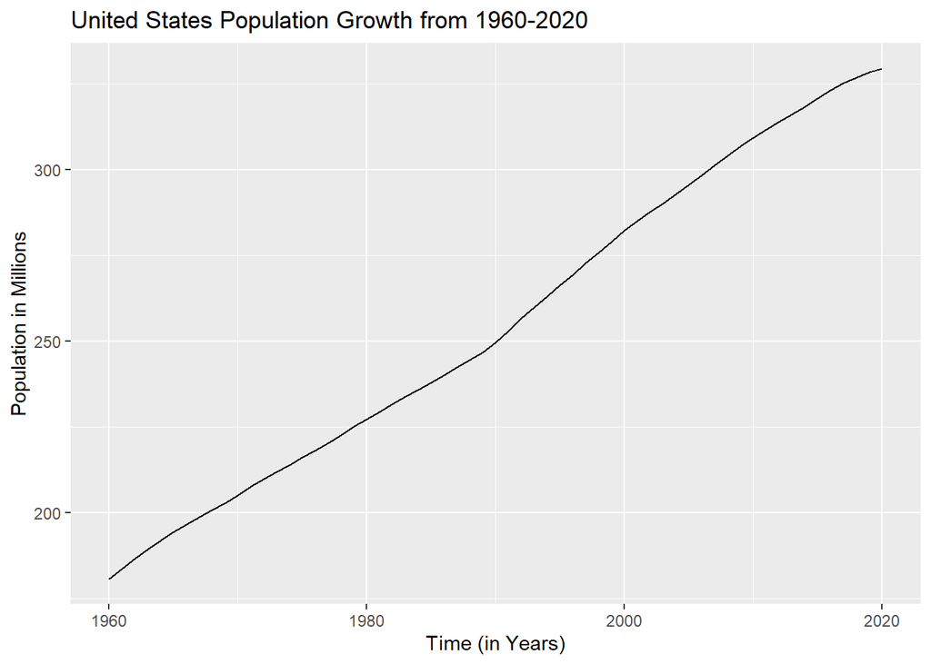

```r
ggplot(filter(stacked_pop_data, CountryName=='United States'),
  aes(x=Date, y=values)) +
    geom_line() +
      ggtitle("United States Population Growth from 1960-2020") +
        xlab("Time (in Years)") +
          ylab("Population in Millions")
```

## Plot a line graph to show changes to population for the chosen countries

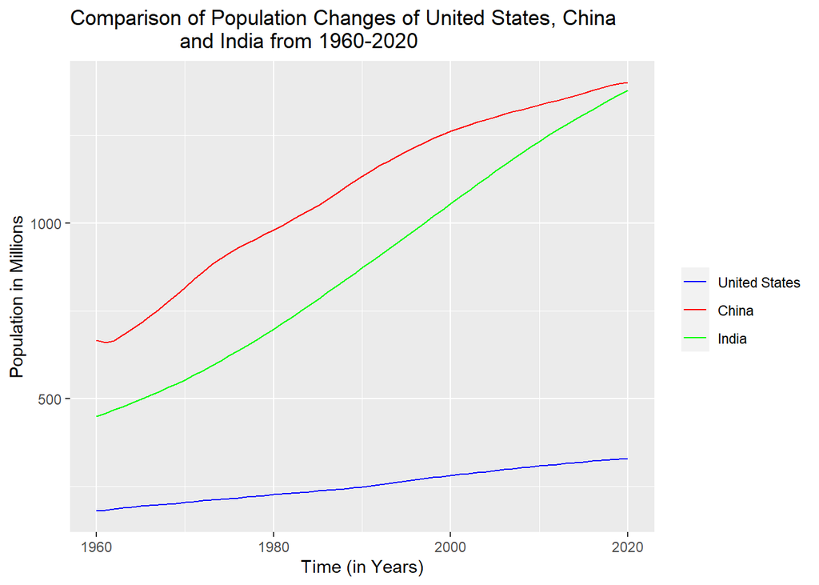

```r
ggplot(filter(stacked_pop_data, CountryName %in% c("United States",   "China", "India")), mapping=aes(x=Date, y=values,      group=CountryName, color=CountryName)) +
  geom_line() +
    scale_colour_manual("",
              breaks = c("United States", "China", "India"),
              values = c("blue", "red", "green")) +
  ggtitle("Comparison of Population Changes of United States, China
                  and India from 1960-2020") +
              xlab("Time (in Years)") +
                ylab("Population in Millions")
```

## How did the population in different parts of the world change over time?

## we will use the stat_summary function and specify geom=“line”

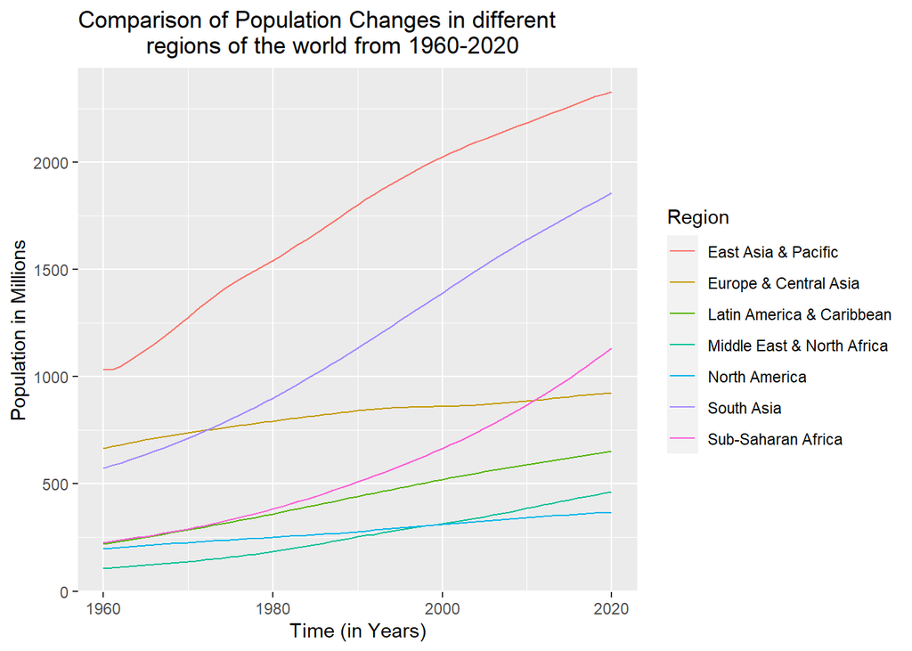

```r
ggplot(stacked_pop_data, mapping=aes(x=Date, y=values, color=Region, group=Region)) +
         stat_summary(fun=sum, geom = "line") +
  ggtitle("Comparison of Population Changes in different
          regions of the world from 1960-2020") +
    xlab("Time (in Years)") +
      ylab("Population in Millions")
```

## Which country or countries have experienced the highest increase/decrease in population over time?

```r
new_d<- stacked_pop_data %>%
  group_by(CountryName) %>%
  mutate(lagged_values = values - lag(values,1))
head(new_d)
```

```
## # A tibble: 6 × 8
## # Groups:   CountryName [6]
##   Country.Code Region            Incom…¹ Count…² values  Year Date       lagge…³
##   <chr>        <chr>             <chr>   <chr>    <dbl> <dbl> <date>       <dbl>
## 1 ABW          Latin America & … High i… Aruba   0.0542  1960 1960-01-01      NA
## 2 AFG          South Asia        Low in… Afghan… 9.00    1960 1960-01-01      NA
## 3 AGO          Sub-Saharan Afri… Lower … Angola  5.45    1960 1960-01-01      NA
## 4 ALB          Europe & Central… Upper … Albania 1.61    1960 1960-01-01      NA
## 5 AND          Europe & Central… High i… Andorra 0.0134  1960 1960-01-01      NA
## 6 ARE          Middle East & No… High i… United… 0.0924  1960 1960-01-01      NA
## # … with abbreviated variable names ¹IncomeGroup, ²CountryName, ³lagged_values
```

```r
new_d %>%
  filter(Date>="1961-01-01") %>%
  group_by(CountryName) %>%
  summarise(sum_diff=sum(lagged_values, na.rm=T)) %>%
    arrange(desc(sum_diff)) %>%
    slice_head(n=5)
```

```
## # A tibble: 5 × 2
##   CountryName sum_diff
##   <chr>          <dbl>
## 1 India           929.
## 2 China           735.
## 3 Indonesia       186.
## 4 Pakistan        176.
## 5 Nigeria         161.
```

```r
new_d %>%
  filter(Date>="1961-01-01") %>%
  group_by(CountryName) %>%
  summarise(sum_diff=sum(lagged_values, na.rm=T)) %>%
  arrange(desc(sum_diff)) %>%
  slice_tail(n=5)
```

```
## # A tibble: 5 × 2
##   CountryName         sum_diff
##   <chr>                  <dbl>
## 1 St. Kitts and Nevis  0.00199
## 2 Croatia             -0.0930
## 3 Latvia              -0.219
## 4 Hungary             -0.234
## 5 Bulgaria            -0.940
```

## Which country or countries have been experiencing the highest increase/decrease in population in the last five (or ten) years?

```r
new_d %>%
  filter(Date>="2015-01-01") %>%
  group_by(CountryName) %>%
  summarise(sum_diff=sum(lagged_values, na.rm=T)) %>%
  arrange(desc(sum_diff)) %>%
  slice_head(n=5)
```

```
## # A tibble: 5 × 2
##   CountryName sum_diff
##   <chr>          <dbl>
## 1 India           84.4
## 2 China           37.8
## 3 Nigeria         29.7
## 4 Pakistan        25.6
## 5 Indonesia       18.4
```

```r
new_d %>%
  filter(Date>="2015-01-01") %>%
  group_by(CountryName) %>%
  summarise(sum_diff=sum(lagged_values, na.rm=T)) %>%
  arrange(desc(sum_diff)) %>%
  slice_tail(n=5)
```

```
## # A tibble: 5 × 2
##   CountryName            sum_diff
##   <chr>                     <dbl>
## 1 "Ukraine"                 -1.14
## 2 "Syrian Arab Republic"    -1.21
## 3 "Italy"                   -1.24
## 4 "Japan"                   -1.44
## 5 "\"Venezuela, RB\""       -1.61
```

## How many people were born in your country (or any other country) during your birth year?

```r
new_d %>%
  filter(Date=="1994-01-01") %>%
  filter(CountryName=="Eswatini") %>%
  group_by(CountryName) %>%
  summarise(num_born=mean(lagged_values, na.rm=T)*1000000)
```

```
## # A tibble: 1 × 2
##   CountryName num_born
##   <chr>          <dbl>
## 1 Eswatini      19916.
```

## It was realized that there are some null coded entries in the income group column. Remove null entries

```r
stacked_pop_data <- subset(stacked_pop_data, IncomeGroup!="null")
```

## How does income group affect a country’s population growth?

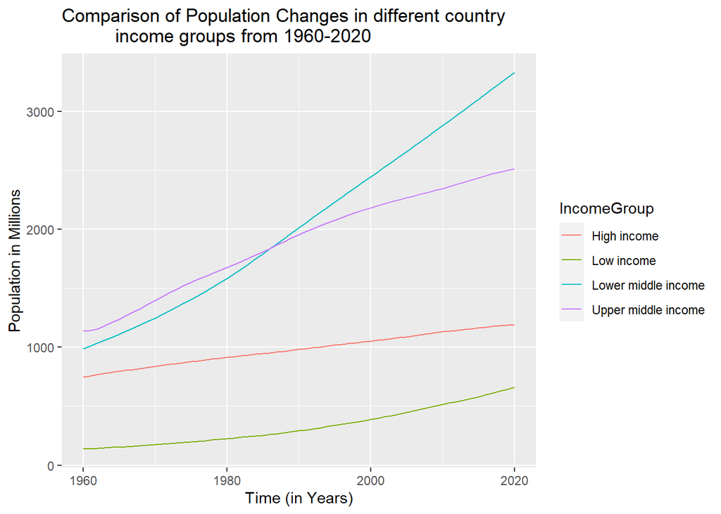

```r
ggplot(stacked_pop_data, mapping=aes(x=Date, y=values, color=IncomeGroup, group=IncomeGroup)) +
  stat_summary(fun=sum, geom = "line") +
  ggtitle("Comparison of Population Changes in different country
          income groups from 1960-2020") +
  xlab("Time (in Years)") +
  ylab("Population in Millions")
```